# cm09 Inclass Exercises

Sahil Jain (95938494)

2018-03-26

Consider the following data, decision boundary, and margin boundaries.

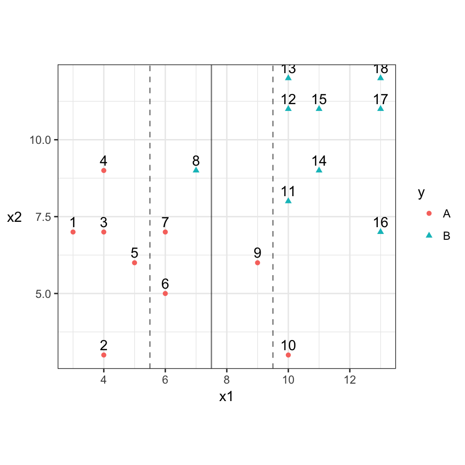

**1. Construct the decision rule according to this classification boundary. How would you classify a new observation that has $x_1=6$ and $x_2=10$?**

We classify “A” whenever
$$x_1 < 7.5$$
and “B” whenever
$$x_1 > 7.5$$

**2. What size is the margin here?**

Margin width is 2.

**3. Which observations receive a penalty? Which observations are the support vectors?**

Observations 6,7,8,9 and 10 would receive a penalty. These are also the support vectors.

**4. What is the total penalty here?**

Penalty for observation 6: 0.25  
Penalty for observation 7: 0.25  
Penalty for observation 8: 1.25  
Penalty for observation 9: 1.75  
Penalty for observation 10: 2.25  
Total: 5.75

**5. Can I choose a bigger margin if my total allowable penalty is 6?**  
Yes, we can choose s slightly bigger margin.

**6. Are the data separable? If so, what are the support vectors?**  
Yes.  
We can draw a diagonal. If we start increasing the margins on either side of the decision boundary, we would hit 4,8 and 9 which would be are support vectors would thus be 4,8, and 9.